# Session7 In-Session Coding Exercise

Sunny

10/31/2019

### 1. Diff-in-Diff

Example Code:

```
## No summary function supplied, defaulting to `mean_se()
```

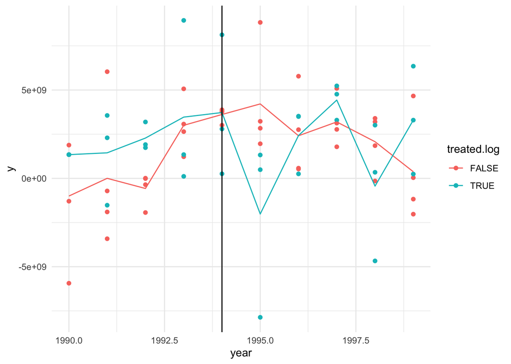

```r
# Getting sample data.
mydata = read.dta("http://dss.princeton.edu/training/Panel101.dta")

# Create a dummy variable to indicate the time when the treatment started. Lets assume that treatment started in 1994. In this case, years before 1994 will have a value of 0 and the year of 1994 and years after 1994 will have a value of 1.
mydata$time = ifelse(mydata$year >= 1994, 1, 0)

# Create a dummy variable to identify the group exposed to the treatment. In this example lets assumed that countries with code country code "E", "F" and "G" were treated (=1).
mydata$treated = ifelse(mydata$country == "E" |
                        mydata$country == "F" |
                        mydata$country == "G", 1, 0)

# Create an interaction between time and treated. We will call this interaction "did".
mydata$did = mydata$time * mydata$treated

mydata = mydata %>%
    mutate(treated.log = (country ==  "E" |
                          country == "F" |
                          country == "G"))

#Not a great example for the DID model, you should justify the control group by proving the parrallel trend before applying DID model.

ggplot(mydata, aes(year, y, color = treated.log)) +
    geom_point(aes(col=treated.log)) +
    stat_summary(geom = 'line') +
    geom_vline(xintercept = 1994) +
    theme_minimal()
```

```r
# Estimating the DID model
# Method 1.
didreg <- lm(y ~ treated + time + did, data = mydata)
summary(didreg)
```

```
##
## Call:
## lm(formula = y ~ treated + time + did, data = mydata)
##
## Residuals:
##        Min         1Q     Median         3Q        Max
## -9.768e+09 -1.623e+09  1.167e+08  1.393e+09  6.807e+09
##
## Coefficients:
##               Estimate Std. Error t value Pr(>|t|)
## (Intercept)  3.581e+08  7.382e+08   0.485   0.6292
## treated      1.776e+09  1.128e+09   1.575   0.1200
## time         2.289e+09  9.530e+08   2.402   0.0191 *
## did         -2.520e+09  1.456e+09  -1.731   0.0882 .
## ---
## Signif. codes:  0 '***' 0.001 '**' 0.01 '*' 0.05 '.' 0.1 ' ' 1
##
## Residual standard error: 2.953e+09 on 66 degrees of freedom
## Multiple R-squared:  0.08273,    Adjusted R-squared:  0.04104
## F-statistic: 1.984 on 3 and 66 DF,  p-value: 0.1249
```

```r
# Method 2.
didreg1 <- lm(y ~ treated*time, data = mydata)
summary(didreg1)
```

```
##
## Call:
## lm(formula = y ~ treated * time, data = mydata)
##
## Residuals:
##        Min         1Q     Median         3Q        Max
## -9.768e+09 -1.623e+09  1.167e+08  1.393e+09  6.807e+09
##
## Coefficients:
##                Estimate Std. Error t value Pr(>|t|)
## (Intercept)   3.581e+08  7.382e+08   0.485   0.6292
## treated       1.776e+09  1.128e+09   1.575   0.1200
## time          2.289e+09  9.530e+08   2.402   0.0191 *
## treated:time -2.520e+09  1.456e+09  -1.731   0.0882 .
## ---
## Signif. codes:  0 '***' 0.001 '**' 0.01 '*' 0.05 '.' 0.1 ' ' 1
##
## Residual standard error: 2.953e+09 on 66 degrees of freedom
## Multiple R-squared:  0.08273,    Adjusted R-squared:  0.04104
## F-statistic: 1.984 on 3 and 66 DF,  p-value: 0.1249
```

#### 2. Heteroskedesticity and Robust Standard Errors

Example code:

```r
#Method 1: this will generate the same result as stata
# import the function from repository
url_robust <- "https://raw.githubusercontent.com/IsidoreBeautrelet/economictheoryblog/master/robust_summary.R"
eval(parse(text = getURL(url_robust, ssl.verifypeer = FALSE)),envir=.GlobalEnv)

summary(didreg1, robust = T)$coefficient
```

```
##                 Estimate Std. Error    t value   Pr(>|t|)
## (Intercept)    358143950  761344811  0.4704097 0.63961323
## treated       1775969673 1045292976  1.6990162 0.09402563
## time          2289454651  900377692  2.5427714 0.01335045
## treated:time -2519511630 1452757862 -1.7342956 0.08753426
```

```r
#Method 2:We will see this function again when we talk about the clustered standard errors.
coeftest(didreg1, vcov = vcovHC(didreg1, cluster = "HC0"))
```

```
##
## t test of coefficients:
##
##                 Estimate  Std. Error t value Pr(>|t|)
## (Intercept)    358143950   788556949  0.4542  0.65119
## treated       1775969672  1094275322  1.6230  0.10936
## time          2289454650   926826784  2.4702  0.01610 *
## treated:time -2519511630  1505437608 -1.6736  0.09894 .
## ---
## Signif. codes:  0 '***' 0.001 '**' 0.01 '*' 0.05 '.' 0.1 ' ' 1
```

#### In-Session Coding:

We are interested in examing the policy effect on whether one family works or not: The earned income tax credit (EITC) policy took effect in the year of 1994; and the group that benefited from the policy was the families with dependent children.

##### 1. write down your estimation equation.

##### 2. write the code for your estimation:

```r
eitc <- read.dta("~/AAE636/Session7/eitc.dta")

## Create the dummies for the time of the treatment and the treatment group.

##variable name: children
#eitc$treated <-

##variable name: year
#eitc$time <-

## Plot the data to show the change

## Run the DID regression
#fit1 <-
#summary(fit1)
```

##### 3. By using your regression equation and estimation results, answer the following questions:

##### a. what is the expected probability of working for one family without children before 1994? what is your estimate?

##### b. what is the expected probability of working for one family without children in and after 1994? what is your estimate?

##### c. what is the expected effect of the policy to the group without children?

##### d. what is the expected probability of working for one family with children before 1994? what is your estimate?

##### e. what is the expected probability of working for one family with children in and after 1994? what is your estimate?

##### f.what is the expected effect of the policy to the group with children? what is your estimate?

##### 4. Adding controls for your regression

##### Do you think not adding the controls could bias your estimation results? Explain.

```r
## Add education and age: variable name "ed" and "age", in your regression

## Run the DID regression with controls
#fit2 <-
#summary(fit2)
```

##### 5. Hypothesis Testing

```r
## t-test of the expected effect of age and education on y (the probability of working) are the same.

## F-test of the expected effect of age and education on y (the probability of working) both equal to 0.
```